# Hyne - Lumber - Dry v Green

JH

03/04/2015

```r
library(lattice)
library(RODBC)
ch = odbcConnect('Hyne',uid='sa',pwd="password12")
```

```r
mypanel = function(x,y,...) {
  panel.abline(c(0,1), col='grey70', lty=2)
  panel.xyplot(x,y,...)
}
X = sqlQuery(ch, "
             select
                m.flitchId, SWILogNumber,
               g.MOE [E.g],
               g.Density [den.g],
               m.swv [v.d],
               h.[Density_kg/m3] [den.d],
               h.[MOE.cltraw] [E.d],
               m.pith,
               m.wane,
               X_MOE/1000. [E.d.chh],
               X_Dens [den.d.chh]
             from (select flitchId, max(pith) pith, max(wane) wane, avg(swv) swv from manualMeas group by flitchId) m left join HyneDryBoards h on h.flitchId=m.flitchId
             left join ecoustic g on m.flitchId=g.flitchId
             left join CHHBoards c on m.flitchId=c.flitchId
             left join (
                select flitchId, max(SWILogNumber) SWILogNumber
                from boardEndImages i, barcode_image bi, boardEndBarcodes b
                where flitchId is not null and i.id=bi.imageId and bi.barcodeId=b.id group by flitchId
             ) f on f.flitchId=m.flitchId
             where g.MOE>0 and g.MOE<>6.5
             ")
X$pith_wane = paste("pith =",X$pith,"; wane =",X$wane)
X$E.d.hitman = X$v.d^2*X$den.d.chh/1e9
X$v.g = sqrt(X$E.g*1e9/X$den.g)
X$E.g.corrected = X$E.g
X$E.g.corrected[X$v.g>4000] = (X$v.g[X$v.g>4000]/2)^2*X$den.g[X$v.g>4000]/1e9
nrow(X)
```

```
## [1] 895
```

895 (of ~1200) boards with the requisite matched green and dry (LHG and manual) data.

## Density

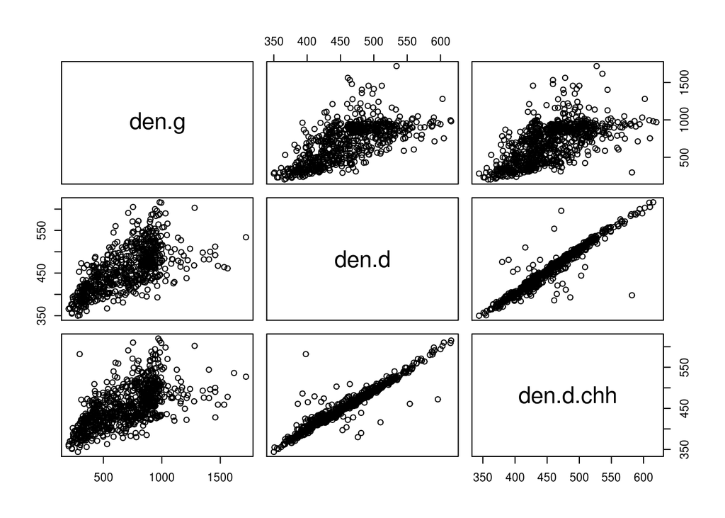

```r
pairs(X[,c("den.g","den.d","den.d.chh")])
```

```r
summary(X[,c("den.g","den.d","den.d.chh")])
```

```
##      den.g            den.d         den.d.chh
##  Min.   : 202.7   Min.   :350.0   Min.   :344.0
##  1st Qu.: 470.8   1st Qu.:420.0   1st Qu.:422.0
##  Median : 733.5   Median :460.0   Median :453.0
##  Mean   : 700.4   Mean   :458.8   Mean   :454.8
##  3rd Qu.: 894.6   3rd Qu.:491.0   3rd Qu.:485.5
##  Max.   :1719.5   Max.   :616.0   Max.   :620.0
##                   NA's   :222     NA's   :80
```

The outliers in the dry Hyne v CHH density plots are probably due to mis-merges in the Hyne dataset. From here on use the CHH density, partly because I have more faith in the CHH merge, but also because there are only 80 boards in the manual measurement set missing from the CHH whereas there are 222 boards missing in the Hyne.

## SWV

2. ViScan (CHH) v Hitman v LHG (Hyne). LHG results waiting of SH. => Use hitman for SWV

## Green v Dry MOE

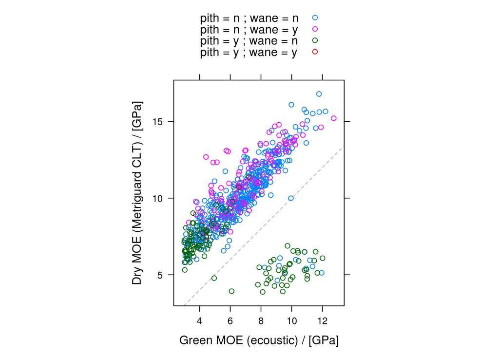

```r
xyplot(E.d ~ E.g, X,
       group=pith_wane,
       auto.key=TRUE,
       panel=mypanel,
       xlab="Green MOE (ecoustic) / [GPa]",
       ylab="Dry MOE (Metriguard CLT) / [GPa]",
       aspect='iso')
```

## Green v Dry SWV

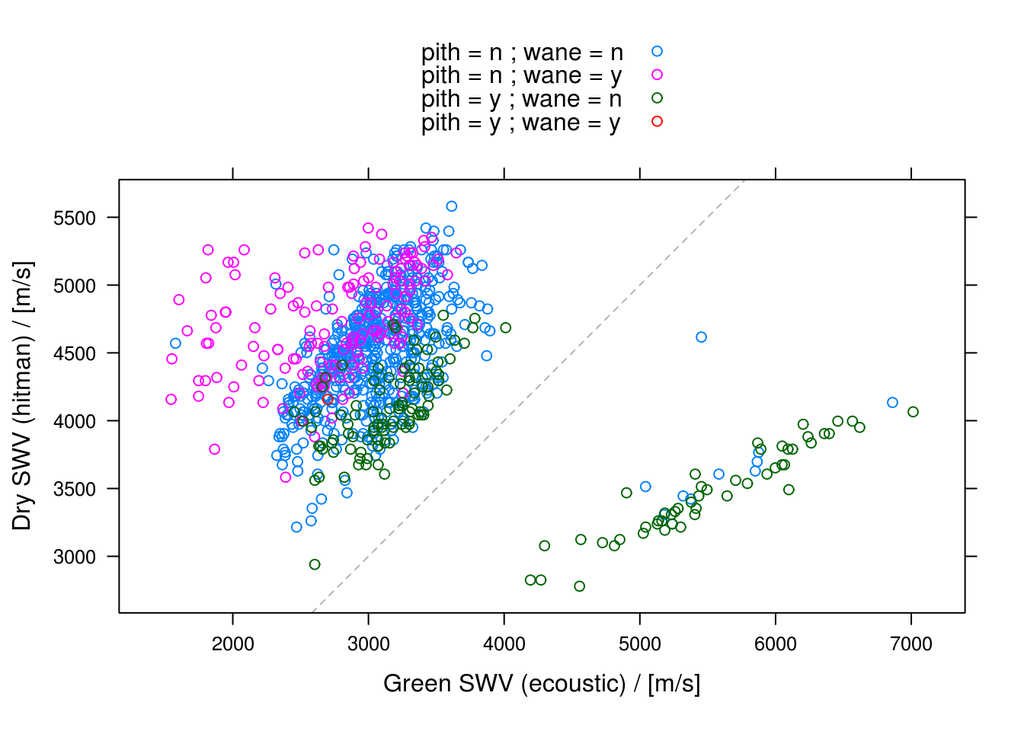

```r
xyplot(v.d ~ v.g, X,
       xlab="Green SWV (ecoustic) / [m/s]",
       ylab="Dry SWV (hitman) / [m/s]",
       group=pith_wane,
       auto.key=TRUE,
       panel=mypanel,
       aspect='iso')
```

Waney boards appear to have less correlation between green and dry SWV. Why? Green density more variable in waney boards?

Cluster of high green SWV, low dry SWV probably due to picking harmonic instead of fundamental. Easily fixed by halving Green SWV and recomputing green MOE.

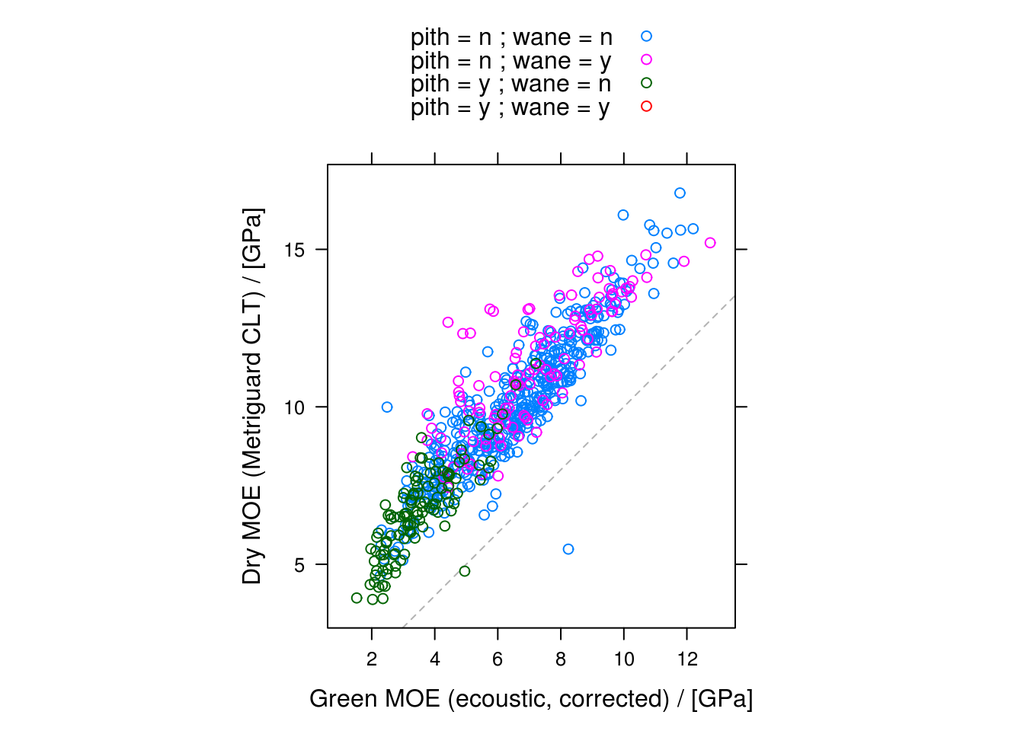

```r
xyplot(E.d ~ E.g.corrected, X,
       group=pith_wane,
       auto.key=TRUE,
       panel=mypanel,
       xlab="Green MOE (ecoustic, corrected) / [GPa]",
       ylab="Dry MOE (Metriguard CLT) / [GPa]",
       aspect='iso')
```

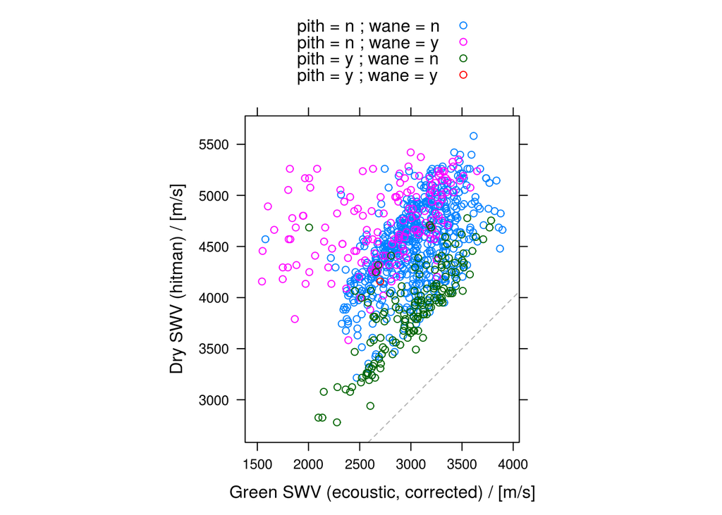

```r
xyplot(v.d ~ sqrt(E.g.corrected/den.g*1e9), X,
       xlab="Green SWV (ecoustic, corrected) / [m/s]",
       ylab="Dry SWV (hitman) / [m/s]",
       group=pith_wane,
       auto.key=TRUE,
       panel=mypanel,
       aspect='iso')
```

## Using Green MOE as a surrogate for Dry MOE

ML has proposed using green board MOE instead of dry MOE to determine log quality. If we did this with the Hyne dataset, would green board MOE be sufficient to correctly classify logs? (I.e rank logs same as dry board MOE would).

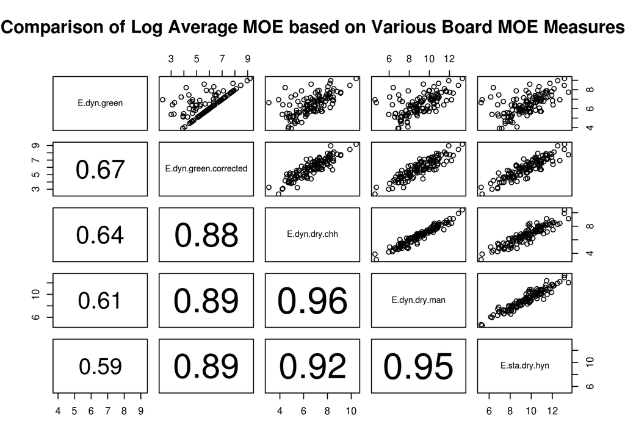

```r
L = sqlQuery(ch, "select * from logs l full join yardTrimmed y on l.SWILogNumber=y.SWILogNumber where l.SWILogNumber is not null and DateAndTime>'2014-08-31 00:00:00' order by l.SWILogNumber")
for (i in 1:nrow(L)) {
  ii=!is.na(X$SWILogNumber) & X$SWILogNumber==L[i,"SWILogNumber"]
  L[i,"nboards"]=sum(ii)
  L[i,"E.dyn.green"]=mean(X$E.g[ii],na.rm=TRUE)
  L[i,"E.dyn.green.corrected"]=mean(X$E.g.corrected[ii],na.rm=TRUE)
  L[i,"E.dyn.dry.chh"]=mean(X$E.d.chh[ii],na.rm=TRUE) # viscan + chh density
  L[i,"E.dyn.dry.man"]=mean(X$E.d.hitman[ii],na.rm=TRUE) # manual + chh density
  L[i,"E.sta.dry.hyn"]=mean(X$E.d[ii],na.rm=TRUE) # clt
  #L[i,"E.dyn.dry.hyn"]=mean(X$E.d.lhg[ii],na.rm=TRUE) # lhg + xry : waiting on SH re-running

}
pairs(L[,c("E.dyn.green","E.dyn.green.corrected","E.dyn.dry.chh","E.dyn.dry.man","E.sta.dry.hyn")],
      lower.panel=function(x, y, digits = 2, prefix = "", cex.cor, ...)
{
    usr <- par("usr"); on.exit(par(usr))
    par(usr = c(0, 1, 0, 1))
    ii=!is.na(x) & !is.na(y)
    r <- abs(cor(x[ii], y[ii]))
    txt <- format(c(r, 0.123456789), digits = digits)[1]
    txt <- paste0(prefix, txt)
    if(missing(cex.cor)) cex.cor <- 0.8/strwidth(txt)
    text(0.5, 0.5, txt, cex = cex.cor * r)
}, main="Comparison of Log Average MOE based on Various Board MOE Measures")
```

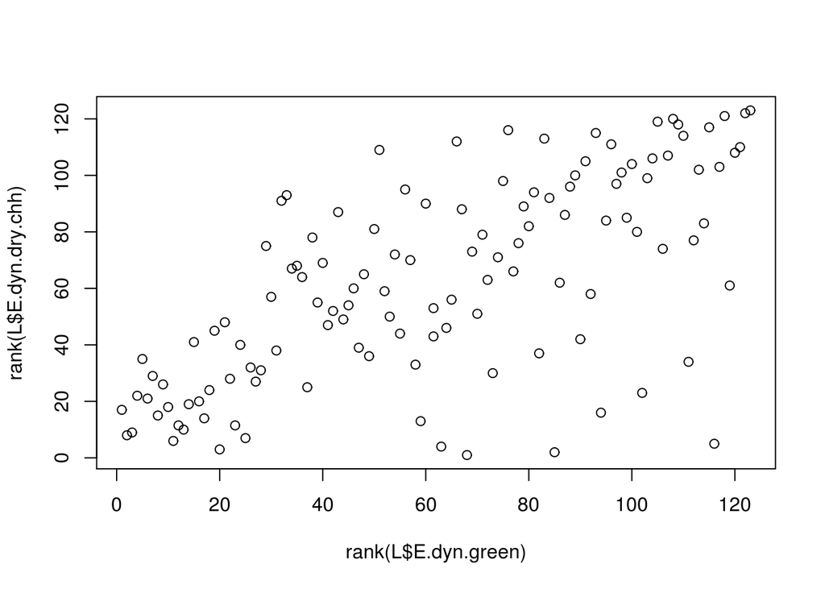

```r
par(mfcol=c(1,1))
plot(rank(L$E.dyn.green), rank(L$E.dyn.dry.chh))
```

```r
#identify(rank(L$E.dyn.green), rank(L$E.dyn.dry.chh),L$SWILogNumber)
t(L[L$SWILogNumber==195,])
```

```
##                       96
## ID                    "119802"
## RoyaltyID             "4"
## SorterID              "4"
## DateAndTime           "2014-08-31 10:07:43"
## da                    "A0001"
## length                "4904.239"
## volume                "0.557555"
## SED                   "353.7869"
## SEDcheck              "354.6332"
## LED                   "428.2396"
## velocity              NA
## kickLog               NA
## logKicked             NA
## logKickedReconciled   NA
## seqPrefix             NA
## seqNumber             NA
## SWILogNumber          "195"
## m_fail                NA
## m_origOrient          NA
## m_nslices             NA
## m_dzmax               NA
## m_dzmin               NA
## m_length              NA
## m_volume              NA
## m_led                 NA
## m_sed                 NA
## m_a0                  NA
## m_a1                  NA
## m_a2                  NA
## m_taper               NA
## m_waist               NA
## m_ovality             NA
## m_whorliness          NA
## m_sweep1              NA
## m_sweep2              NA
## s_archetype           NA
## c_f1                  NA
## c_f2                  NA
## c_grade               NA
## c_retval              NA
## c_velocity            NA
## SWILogNumber.1        "195"
## length.1              "4.91"
## SED.1                 "349"
## LED.1                 "453"
## weight                "479"
## f1                    "305"
## f2                    "614"
## SWV                   "2995.1"
## nboards               "6"
## E.dyn.green           "8.221667"
## E.dyn.green.corrected "4.177917"
## E.dyn.dry.chh         "4.444"
## E.dyn.dry.man         "6.409473"
## E.sta.dry.hyn         "6.403894"
```

In the Hyne dataset, without correcting for boards whose SWV is 2x what it should be, green and dry board MOE rank logs quite differently. E.g. green MOE puts log 195 in the top 10%, whereas dry puts it in the bottom 10%!

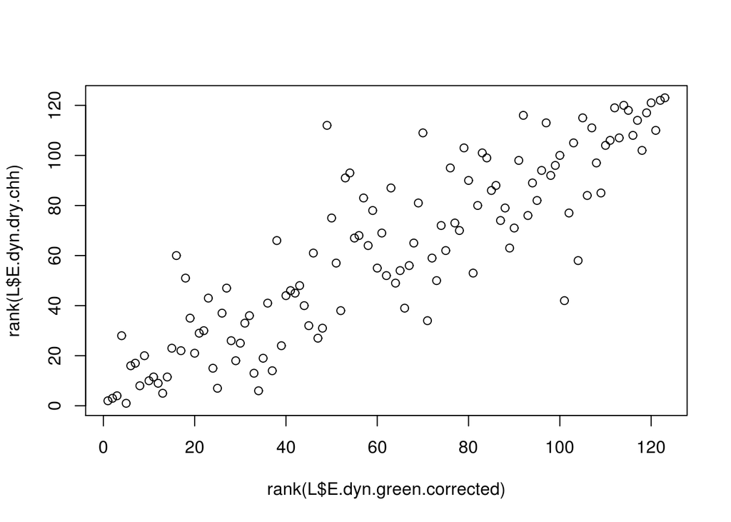

```r
par(mfcol=c(1,1))
plot(rank(L$E.dyn.green.corrected), rank(L$E.dyn.dry.chh))
```

```r
#identify(rank(L$E.dyn.green.corrected), rank(L$E.dyn.dry.chh),L$SWILogNumber)
t(L[L$SWILogNumber==212,])
```

```
##                       112
## ID                    "119839"
## RoyaltyID             "41"
## SorterID              "41"
## DateAndTime           "2014-08-31 10:56:30"
## da                    "A0001"
## length                "4941.011"
## volume                "0.31915"
## SED                   "279.7233"
## SEDcheck              "283.7039"
## LED                   "292.6615"
## velocity              "3438.944"
## kickLog               "0"
## logKicked             NA
## logKickedReconciled   NA
## seqPrefix             NA
## seqNumber             NA
## SWILogNumber          "212"
## m_fail                NA
## m_origOrient          "SE first"
## m_nslices             "46"
## m_dzmax               "101.6"
## m_dzmin               "101.6"
## m_length              "4724.4"
## m_volume              "0.2954085"
## m_led                 "294.0543"
## m_sed                 "285.0128"
## m_a0                  "273.2106"
## m_a1                  "40.69744"
## m_a2                  "-21.32204"
## m_taper               "4.101135"
## m_waist               "-0.2388226"
## m_ovality             "0.0006084246"
## m_whorliness          "0.622408"
## m_sweep1              "2.408865"
## m_sweep2              "0.3039997"
## s_archetype           NA
## c_f1                  "348"
## c_f2                  "0"
## c_grade               "2"
## c_retval              "1"
## c_velocity            "3826"
## SWILogNumber.1        "212"
## length.1              "4.91"
## SED.1                 "272"
## LED.1                 "314"
## weight                "294"
## f1                    "352"
## f2                    "689"
## SWV                   "3456.64"
## nboards               "5"
## E.dyn.green           "6.498"
## E.dyn.green.corrected "5.661"
## E.dyn.dry.chh         "8.4272"
## E.dyn.dry.man         "10.48374"
## E.sta.dry.hyn         "9.857958"
```

Post-correction, the rank switching is reduced to what is probably an acceptable level.

## Dynamic v Bending MOE

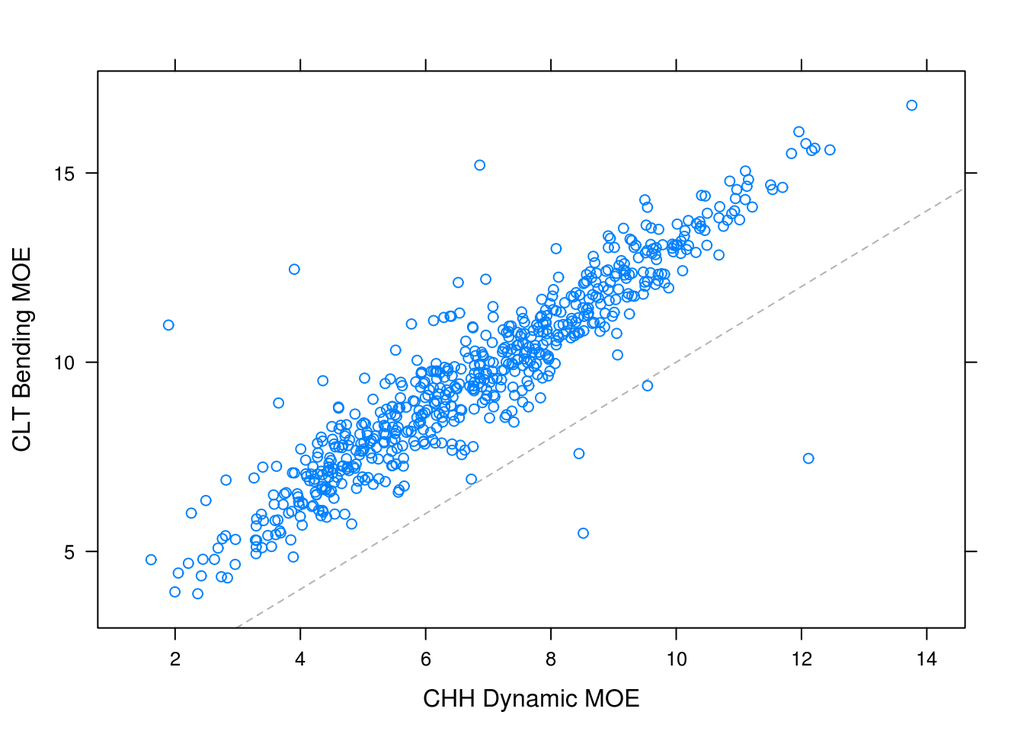

```r
mypanel=function(...) {
          panel.abline(c(0,1),col='grey70',lty=2)
          panel.xyplot(...)
          }
xyplot(E.d ~ E.d.chh, X, panel=mypanel, xlab="CHH Dynamic MOE", ylab="CLT Bending MOE")
```

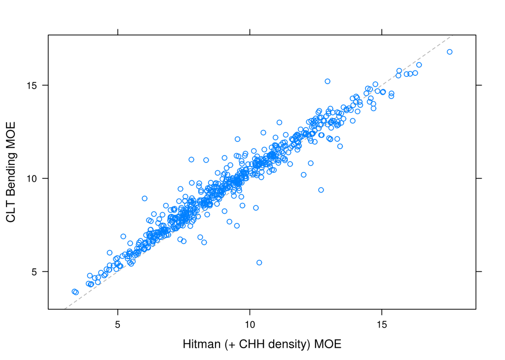

```r
xyplot(E.d ~ E.d.hitman, X, panel=mypanel, xlab="Hitman (+ CHH density) MOE", ylab="CLT Bending MOE")
```

```r
summary(m <- lm(E.d ~ E.d.chh, X))
```

```
##
## Call:
## lm(formula = E.d ~ E.d.chh, data = X)
##
## Residuals:
##     Min      1Q  Median      3Q     Max
## -7.6960 -0.4837 -0.0360  0.4700  6.4716
##
## Coefficients:
##             Estimate Std. Error t value Pr(>|t|)
## (Intercept)  2.53610    0.12695   19.98   <2e-16 ***
## E.d.chh      1.04179    0.01778   58.59   <2e-16 ***
## ---
## Signif. codes:  0 '***' 0.001 '**' 0.01 '*' 0.05 '.' 0.1 ' ' 1
##
## Residual standard error: 0.9625 on 619 degrees of freedom
##   (274 observations deleted due to missingness)
## Multiple R-squared:  0.8472, Adjusted R-squared:  0.847
## F-statistic:  3433 on 1 and 619 DF,  p-value: < 2.2e-16
```

```r
summary(m.0 <- lm(E.d ~ E.d.chh + 0, X))
```

```
##
## Call:
## lm(formula = E.d ~ E.d.chh + 0, data = X)
##
## Residuals:
##     Min      1Q  Median      3Q     Max
## -9.2579 -0.4841  0.2292  0.8995  8.3665
##
## Coefficients:
##         Estimate Std. Error t value Pr(>|t|)
## E.d.chh 1.380130   0.006931   199.1   <2e-16 ***
## ---
## Signif. codes:  0 '***' 0.001 '**' 0.01 '*' 0.05 '.' 0.1 ' ' 1
##
## Residual standard error: 1.233 on 620 degrees of freedom
##   (274 observations deleted due to missingness)
## Multiple R-squared:  0.9846, Adjusted R-squared:  0.9846
## F-statistic: 3.965e+04 on 1 and 620 DF,  p-value: < 2.2e-16
```

```r
summary(m.hit <- lm(E.d ~ E.d.hitman, X))
```

```
##
## Call:
## lm(formula = E.d ~ E.d.hitman, data = X)
##
## Residuals:
##     Min      1Q  Median      3Q     Max
## -5.1740 -0.2546 -0.0064  0.2444  2.7180
##
## Coefficients:
##             Estimate Std. Error t value Pr(>|t|)
## (Intercept) 1.134354   0.085794   13.22   <2e-16 ***
## E.d.hitman  0.919147   0.008943  102.78   <2e-16 ***
## ---
## Signif. codes:  0 '***' 0.001 '**' 0.01 '*' 0.05 '.' 0.1 ' ' 1
##
## Residual standard error: 0.5794 on 619 degrees of freedom
##   (274 observations deleted due to missingness)
## Multiple R-squared:  0.9446, Adjusted R-squared:  0.9446
## F-statistic: 1.056e+04 on 1 and 619 DF,  p-value: < 2.2e-16
```

```r
AIC(m,m.0)
```

```
##     df      AIC
## m    3 1718.813
## m.0  2 2025.799
```

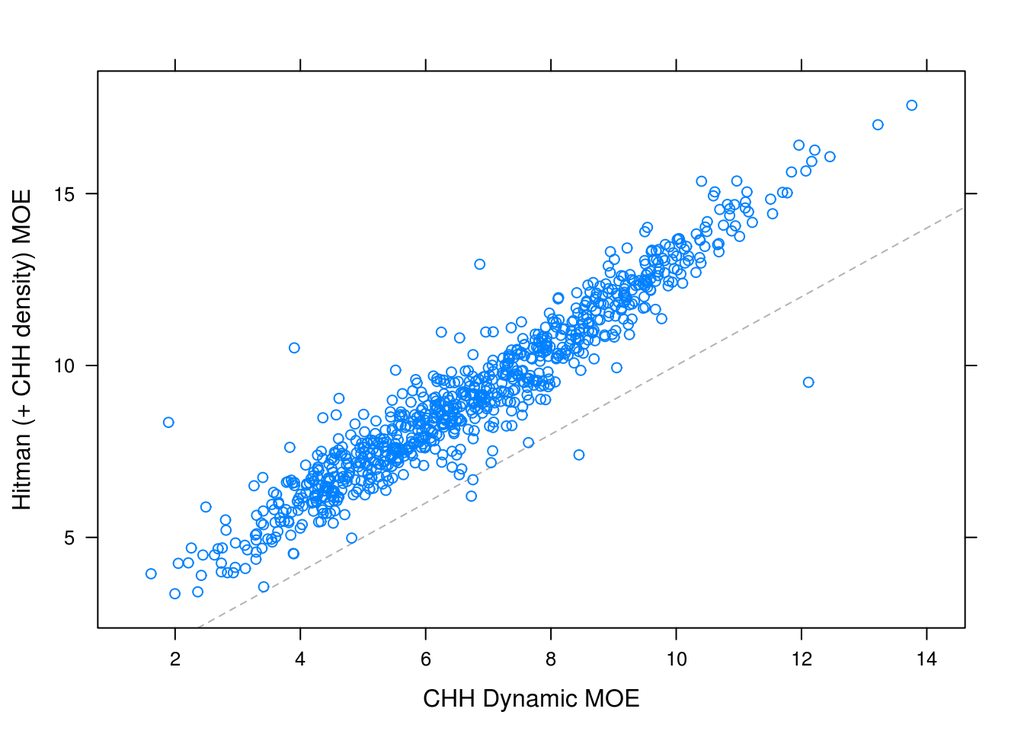

```r
xyplot(E.d.hitman ~ E.d.chh, X, panel=mypanel, xlab="CHH Dynamic MOE", ylab="Hitman (+ CHH density) MOE")
```

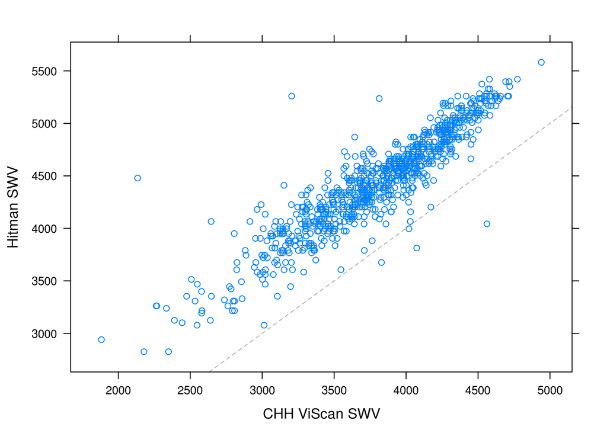

```r
xyplot(sqrt(E.d.hitman*1e9/den.d.chh) ~ sqrt(E.d.chh*1e9/den.d.chh), X, panel=mypanel, xlab="CHH ViScan SWV", ylab="Hitman SWV")
```

```r
library(MASS)
summary(m.hit.swv <- rlm(sqrt(E.d.hitman*1e9/den.d.chh) ~ sqrt(E.d.chh*1e9/den.d.chh), X))
```

```
##
## Call: rlm(formula = sqrt(E.d.hitman * 1e+09/den.d.chh) ~ sqrt(E.d.chh *
##     1e+09/den.d.chh), data = X)
## Residuals:
##       Min        1Q    Median        3Q       Max
## -1102.424  -102.577     4.539   101.482  1566.715
##
## Coefficients:
##                                 Value    Std. Error t value
## (Intercept)                     949.1990  43.5313    21.8050
## sqrt(E.d.chh * 1e+09/den.d.chh)   0.9197   0.0114    80.7798
##
## Residual standard error: 151.7 on 813 degrees of freedom
##   (80 observations deleted due to missingness)
```

Outliers probably due to Hyne mis-merge.

Static MOE (Hyne CLT) greater than dynamic (CHH). Offset is better model than different slope.

Hitman and CHH density good estimator of Hyne CLT MOE. Signs of nonlinearity?